# Exploring FIFA Ratings and motivation

2024-01-25

# Understanding distributions

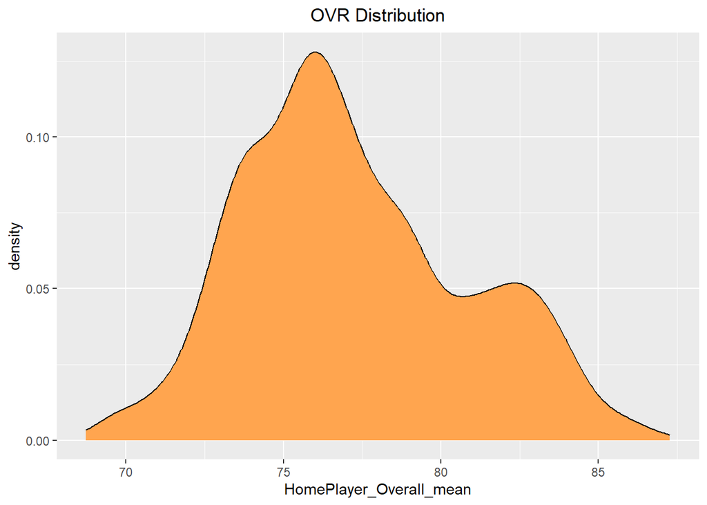

```r
ggplot(data=data, aes(x=HomePlayer_Overall_mean)) +
  geom_density(fill="tan1") + labs(title="OVR Distribution") + theme(plot.title = element_text(hjust = 0.5))
```

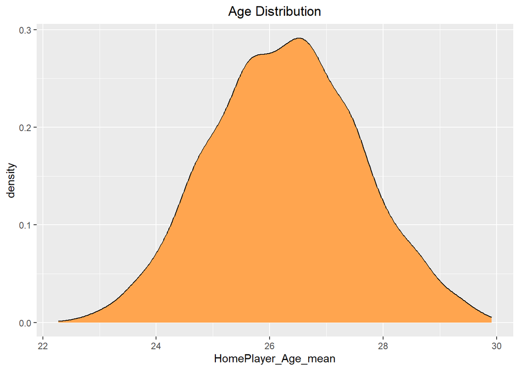

```r
ggplot(data=data, aes(x=HomePlayer_Age_mean)) +
  geom_density(fill="tan1") + labs(title="Age Distribution") + theme(plot.title = element_text(hjust = 0.5))
```

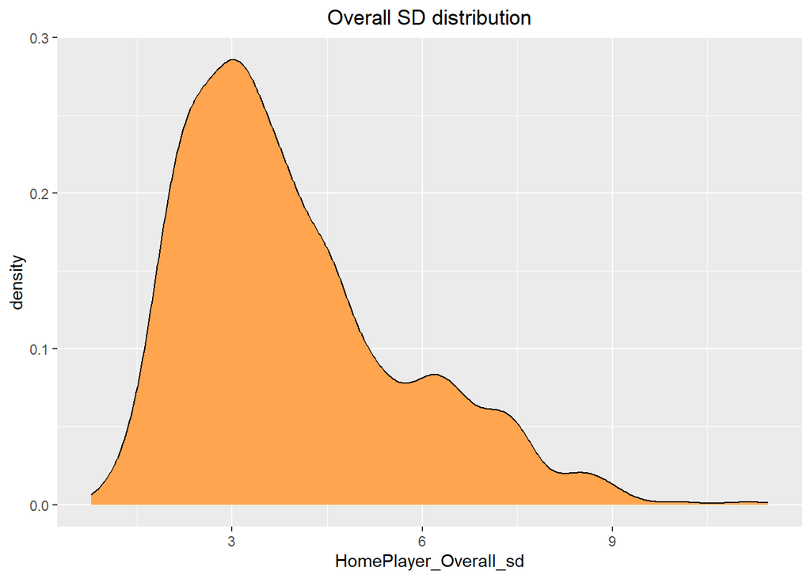

```r
ggplot(data=data, aes(x=HomePlayer_Overall_sd)) +
  geom_density(fill="tan1") + labs(title="Overall SD distribution") + theme(plot.title = element_text(hjust = 0.5))
```

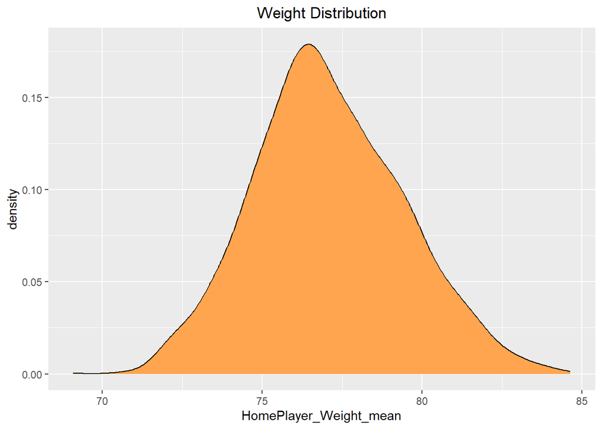

```r
ggplot(data=data, aes(x=HomePlayer_Weight_mean)) +
  geom_density(fill="tan1") + labs(title="Weight Distribution") + theme(plot.title = element_text(hjust = 0.5))
```

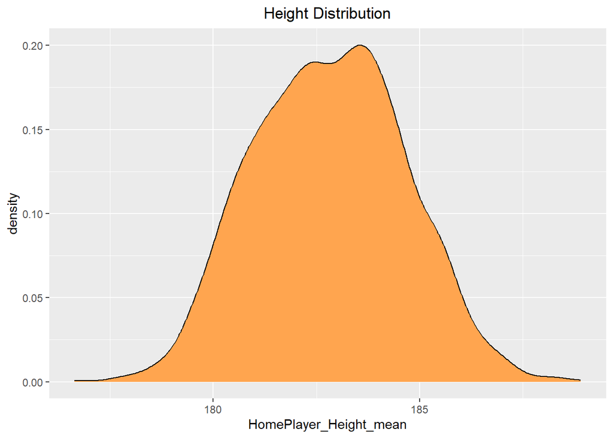

```r
ggplot(data=data, aes(x=HomePlayer_Height_mean)) +
  geom_density(fill="tan1") + labs(title="Height Distribution") + theme(plot.title = element_text(hjust = 0.5))
```

What we can see is that mean values distributions are close to normal and the sd reminds us of the Xi^2 Distribution

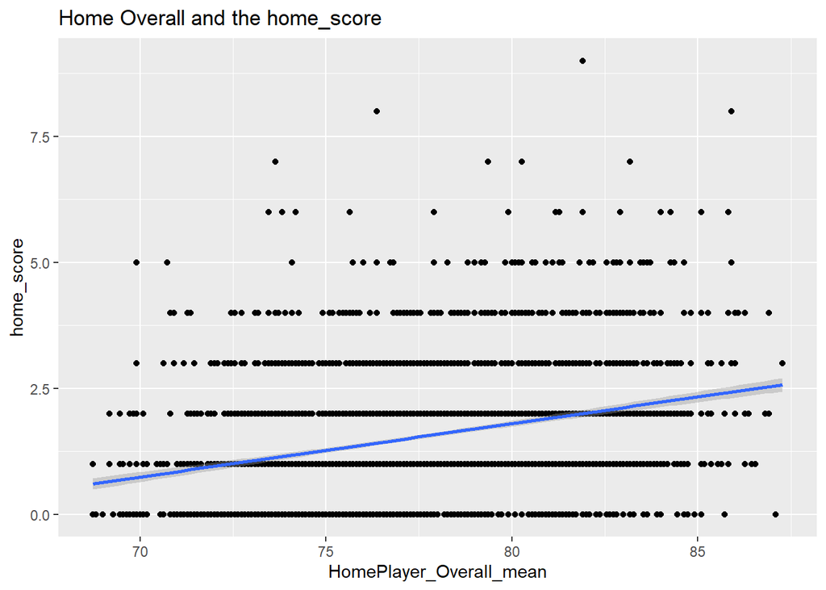

```r
ggplot(data = data, aes(x = HomePlayer_Overall_mean,
                       y = home_score)) +
  geom_point() + stat_smooth(method = "lm") +
  ggtitle("Home Overall and the home_score")
```

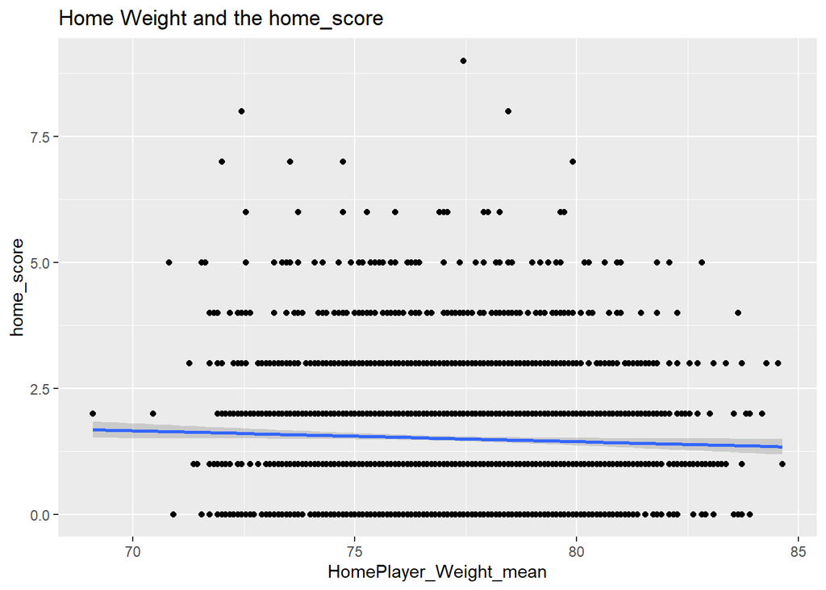

```r
ggplot(data = data, aes(x = HomePlayer_Weight_mean,
                       y = home_score)) +
  geom_point() + stat_smooth(method = "lm") +
  ggtitle("Home Weight and the home_score")
```

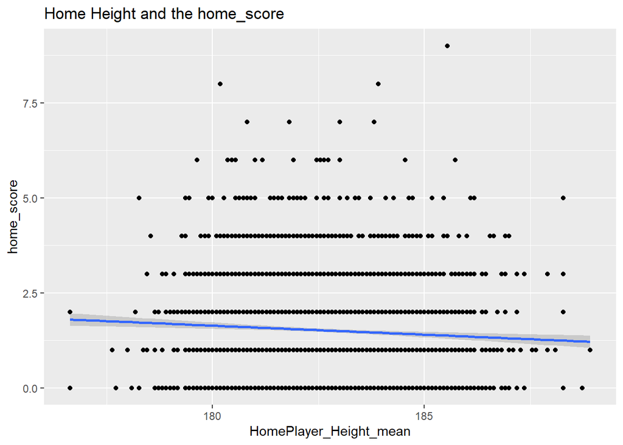

```r
ggplot(data = data, aes(x = HomePlayer_Height_mean,
                       y = home_score)) +
  geom_point() + stat_smooth(method = "lm") +
  ggtitle("Home Height and the home_score")
```

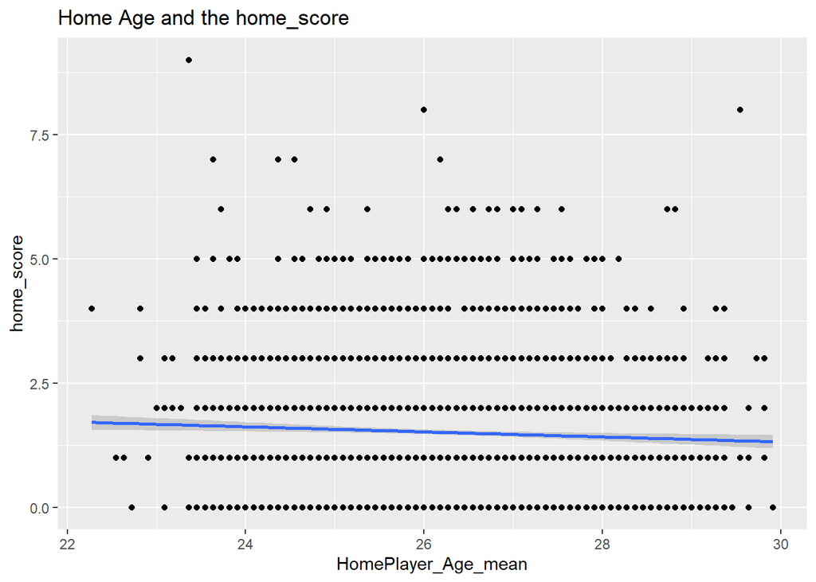

```r
ggplot(data = data, aes(x = HomePlayer_Age_mean,
                       y = home_score)) +
  geom_point() + stat_smooth(method = "lm") +
  ggtitle("Home Age and the home_score")
```

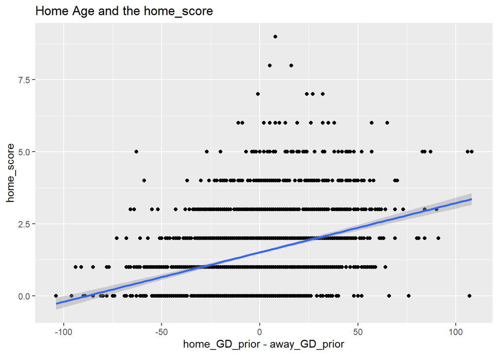

```r
ggplot(data = data, aes(x = home_GD_prior- away_GD_prior,
                       y = home_score)) +
  geom_point() + stat_smooth(method = "lm") +
  ggtitle("Home Age and the home_score")
```

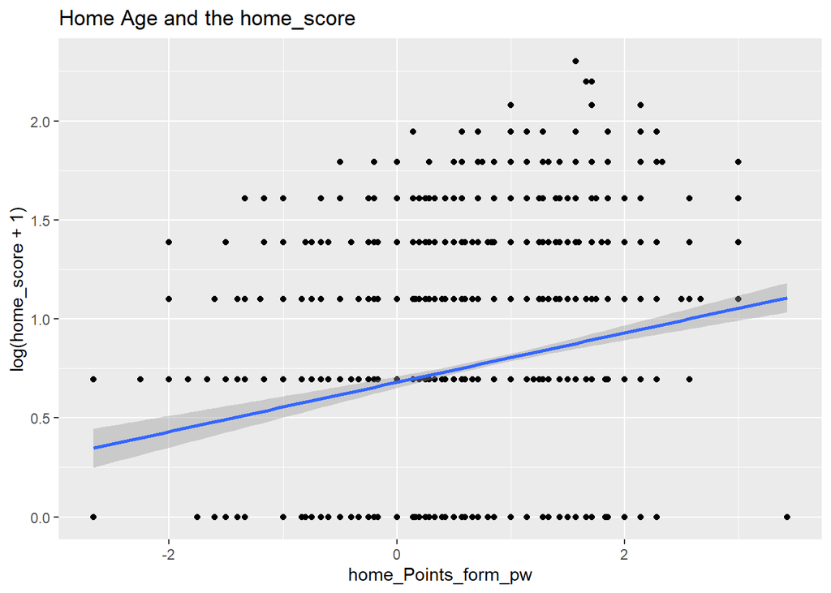

```r
ggplot(data = data, aes(x = home_Points_form_pw,
                       y = log(home_score+1))) +
  geom_point() + stat_smooth(method = "lm") +
  ggtitle("Home Age and the home_score")
```

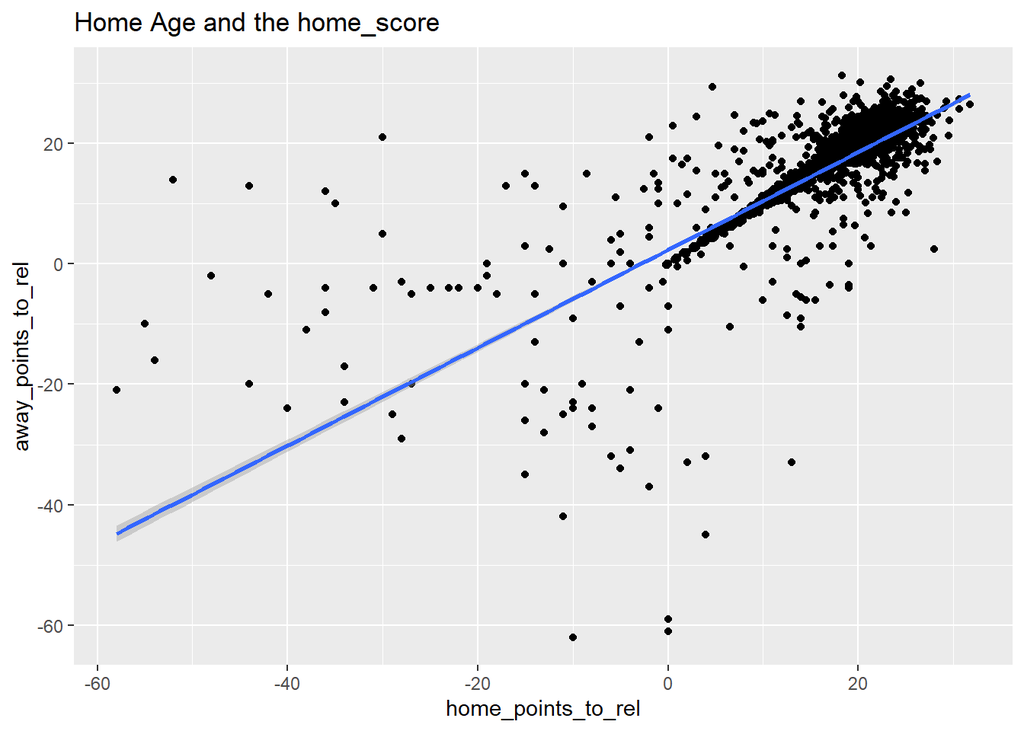

```r
ggplot(data = data, aes(x = home_points_to_rel,
                       y = away_points_to_rel)) +
  geom_point() + stat_smooth(method = "lm") +
  ggtitle("Home Age and the home_score")
```

Why is it?

Maybe because for some areas of the age, raising the average could be beneficial, for example: A team who is full of very young and inexperienced players could be worse than a team full of 26-30 year old players. It could also be true for both height and weight. Weight is self explanatory, but height could give us the idea, that for example there is connection between player height and speed / agility.

How can we show it?

Maybe we can try when running our models, keep in mind adding a squared version of height weight and age

```r
teams_lm = lm(data=data, formula =  I(home_score-away_score) ~
                home_team_name+away_team_name)
summary(teams_lm)
```

```
##
## Call:
## lm(formula = I(home_score - away_score) ~ home_team_name + away_team_name,
##     data = data)
##
## Residuals:
##     Min      1Q  Median      3Q     Max
## -8.9372 -1.0813 -0.0153  1.0246  7.9065
##
## Coefficients:
##                                       Estimate Std. Error t value Pr(>|t|)
## (Intercept)                            0.39994    0.24238   1.650  0.09904 .
## home_team_nameArsenal                  1.16656    0.21680   5.381 7.99e-08 ***
## home_team_nameAston Villa             -0.21954    0.24059  -0.912  0.36158
## home_team_nameBrentford                0.23046    0.41668   0.553  0.58025
## home_team_nameBrighton & Hove Albion  -0.07717    0.24067  -0.321  0.74849
## home_team_nameBurnley                 -0.08383    0.22266  -0.376  0.70659
## home_team_nameCardiff City            -0.75766    0.41668  -1.818  0.06911 .
## home_team_nameChelsea                  1.05962    0.21680   4.887 1.08e-06 ***
## home_team_nameCrystal Palace          -0.01399    0.21680  -0.065  0.94855
## home_team_nameEverton                  0.47247    0.21680   2.179  0.02939 *
## home_team_nameFulham                  -0.69267    0.31829  -2.176  0.02962 *
## home_team_nameHuddersfield Town       -0.62791    0.31818  -1.973  0.04854 *
## home_team_nameHull City               -0.19213    0.31840  -0.603  0.54628
## home_team_nameLeeds United            -0.13889    0.31839  -0.436  0.66270
## home_team_nameLeicester City           0.55719    0.21680   2.570  0.01022 *
## home_team_nameLiverpool                1.46761    0.21680   6.769 1.55e-11 ***
## home_team_nameManchester City          1.88913    0.21680   8.714  < 2e-16 ***
## home_team_nameManchester United        0.99469    0.21680   4.588 4.66e-06 ***
## home_team_nameMiddlesbrough           -0.19454    0.41663  -0.467  0.64058
## home_team_nameNewcastle United         0.15347    0.22270   0.689  0.49080
## home_team_nameNorwich City            -0.74436    0.27783  -2.679  0.00742 **
## home_team_nameQueens Park Rangers      0.07695    0.41659   0.185  0.85346
## home_team_nameSheffield United         0.02391    0.31832   0.075  0.94013
## home_team_nameSouthampton              0.22906    0.21680   1.057  0.29080
## home_team_nameStoke City               0.08075    0.25524   0.316  0.75175
## home_team_nameSunderland              -0.35036    0.27794  -1.261  0.20756
## home_team_nameSwansea City            -0.01161    0.25524  -0.045  0.96372
## home_team_nameTottenham Hotspur        1.12767    0.21680   5.201 2.11e-07 ***
## home_team_nameWatford                 -0.23983    0.23029  -1.041  0.29776
```

[output cut: 25 more lines]

```
## away_team_nameSouthampton             -0.30115    0.21680  -1.389  0.16492
## away_team_nameStoke City              -0.06808    0.25524  -0.267  0.78969
## away_team_nameSunderland               0.03840    0.27794   0.138  0.89012
## away_team_nameSwansea City            -0.07294    0.25524  -0.286  0.77507
## away_team_nameTottenham Hotspur       -1.22754    0.21680  -5.662 1.64e-08 ***
## away_team_nameWatford                 -0.01163    0.23029  -0.050  0.95973
## away_team_nameWest Bromwich Albion    -0.14168    0.24051  -0.589  0.55587
## away_team_nameWest Ham United         -0.55705    0.21680  -2.569  0.01024 *
## away_team_nameWolverhampton Wanderers -0.60853    0.25538  -2.383  0.01724 *
## ---
## Signif. codes:  0 '***' 0.001 '**' 0.01 '*' 0.05 '.' 0.1 ' ' 1
##
## Residual standard error: 1.655 on 2977 degrees of freedom
## Multiple R-squared:  0.2346, Adjusted R-squared:  0.2187
## F-statistic: 14.72 on 62 and 2977 DF,  p-value: < 2.2e-16
```

```r
data <- data%>%
  mutate(win = ifelse(home_score>away_score, 1, 0))

# and one without interactions
teams_lr = glm(data=data, formula = win ~ home_team_name + away_team_name, family='binomial')
summary(teams_lr)
```

```
##
## Call:
## glm(formula = win ~ home_team_name + away_team_name, family = "binomial",
##     data = data)
##
## Deviance Residuals:
##     Min       1Q   Median       3Q      Max
## -2.0994  -0.9750  -0.5887   1.0367   2.2513
##
## Coefficients:
##                                        Estimate Std. Error z value Pr(>|z|)
## (Intercept)                           -0.008801   0.314743  -0.028 0.977693
## home_team_nameArsenal                  1.252440   0.285108   4.393 1.12e-05 ***
## home_team_nameAston Villa             -0.350083   0.325136  -1.077 0.281602
## home_team_nameBrentford                0.082698   0.543860   0.152 0.879141
## home_team_nameBrighton & Hove Albion  -0.355900   0.324659  -1.096 0.272980
## home_team_nameBurnley                 -0.097320   0.293490  -0.332 0.740196
## home_team_nameCardiff City            -0.177032   0.558020  -0.317 0.751054
## home_team_nameChelsea                  0.946085   0.281523   3.361 0.000778 ***
## home_team_nameCrystal Palace          -0.195571   0.286937  -0.682 0.495504
## home_team_nameEverton                  0.418948   0.280714   1.492 0.135585
## home_team_nameFulham                  -0.730944   0.465707  -1.570 0.116523
## home_team_nameHuddersfield Town       -0.747296   0.465304  -1.606 0.108266
## home_team_nameHull City               -0.082715   0.421020  -0.196 0.844247
## home_team_nameLeeds United            -0.150988   0.424887  -0.355 0.722320
## home_team_nameLeicester City           0.552021   0.280383   1.969 0.048975 *
## home_team_nameLiverpool                1.326937   0.286187   4.637 3.54e-06 ***
## home_team_nameManchester City          1.729719   0.295317   5.857 4.71e-09 ***
## home_team_nameManchester United        0.920615   0.281370   3.272 0.001068 **
## home_team_nameMiddlesbrough           -0.779690   0.619268  -1.259 0.208012
## home_team_nameNewcastle United         0.091237   0.290912   0.314 0.753806
## home_team_nameNorwich City            -0.618751   0.393031  -1.574 0.115417
## home_team_nameQueens Park Rangers     -0.189577   0.556887  -0.340 0.733538
## home_team_nameSheffield United         0.219975   0.410871   0.535 0.592383
## home_team_nameSouthampton              0.061982   0.283360   0.219 0.826854
## home_team_nameStoke City               0.127544   0.331913   0.384 0.700778
## home_team_nameSunderland              -0.728786   0.397284  -1.834 0.066592 .
## home_team_nameSwansea City             0.212017   0.330757   0.641 0.521519
## home_team_nameTottenham Hotspur        1.196940   0.284387   4.209 2.57e-05 ***
## home_team_nameWatford                 -0.142647   0.304687  -0.468 0.639658
```

[output cut: 29 more lines]

```
## away_team_nameTottenham Hotspur       -1.241431   0.287381  -4.320 1.56e-05 ***
## away_team_nameWatford                  0.108879   0.297018   0.367 0.713937
## away_team_nameWest Bromwich Albion    -0.347325   0.307262  -1.130 0.258313
## away_team_nameWest Ham United         -0.571372   0.278370  -2.053 0.040115 *
## away_team_nameWolverhampton Wanderers -0.817503   0.330690  -2.472 0.013432 *
## ---
## Signif. codes:  0 '***' 0.001 '**' 0.01 '*' 0.05 '.' 0.1 ' ' 1
##
## (Dispersion parameter for binomial family taken to be 1)
##
##     Null deviance: 4175.8  on 3039  degrees of freedom
## Residual deviance: 3661.6  on 2977  degrees of freedom
## AIC: 3787.6
##
## Number of Fisher Scoring iterations: 4
```

```r
lm_model <- felm(data=data, formula = home_score ~
                 HomePlayer_Overall_mean +
                 HomePlayer_Overall_min +
                 HomePlayer_Overall_max +
                 HomePlayer_Overall_sd +
                 HomePlayer_Height_mean + I(HomePlayer_Height_mean^2)  +
                 HomePlayer_Weight_mean + I(HomePlayer_Weight_mean^2)  +
                 home_Points_prior + away_Points_prior+
                 HomePlayer_Age_mean + I(HomePlayer_Age_mean^2) |
                home_team_name+ away_team_name  + fixture | 0 | 0)

summary(lm_model)
```

```
##
## Call:
##    felm(formula = home_score ~ HomePlayer_Overall_mean + HomePlayer_Overall_min +      HomePlayer_Overall_max + HomePlayer_Overall_sd + HomePlayer_Height_mean +      I(HomePlayer_Height_mean^2) + HomePlayer_Weight_mean + I(HomePlayer_Weight_mean^2) +      home_Points_prior + away_Points_prior + H…
##
## Residuals:
##     Min      1Q  Median      3Q     Max
## -3.3514 -0.6892 -0.0005  0.5631  6.9363
##
## Coefficients:
##                              Estimate Std. Error t value Pr(>|t|)
## HomePlayer_Overall_mean      0.047293   0.027896   1.695 0.090159 .
## HomePlayer_Overall_min      -0.011649   0.017930  -0.650 0.515950
## HomePlayer_Overall_max       0.007701   0.027004   0.285 0.775538
## HomePlayer_Overall_sd        0.011310   0.063335   0.179 0.858284
## HomePlayer_Height_mean       2.735895   2.498745   1.095 0.273682
## I(HomePlayer_Height_mean^2) -0.007373   0.006834  -1.079 0.280779
## HomePlayer_Weight_mean      -0.737419   0.601897  -1.225 0.220652
## I(HomePlayer_Weight_mean^2)  0.004702   0.003887   1.210 0.226567
## home_Points_prior            0.009393   0.002498   3.760 0.000174 ***
## away_Points_prior           -0.007559   0.002482  -3.046 0.002348 **
## HomePlayer_Age_mean          0.169022   0.650196   0.260 0.794923
## I(HomePlayer_Age_mean^2)    -0.003596   0.012355  -0.291 0.771040
## ---
## Signif. codes:  0 '***' 0.001 '**' 0.01 '*' 0.05 '.' 0.1 ' ' 1
##
## Residual standard error: 1.241 on 2112 degrees of freedom
## Multiple R-squared(full model): 0.3643   Adjusted R-squared: 0.08529
## Multiple R-squared(proj model): 0.01716   Adjusted R-squared: -0.4142
## F-statistic(full model):1.306 on 927 and 2112 DF, p-value: 5.541e-07
## F-statistic(proj model): 3.073 on 12 and 2112 DF, p-value: 0.0002549
## *** Standard errors may be too high due to more than 2 groups and exactDOF=FALSE
```

```r
lm_model <- felm(data=data, formula = home_score ~
                 HomePlayer_Overall_mean +
                 HomePlayer_Overall_min +
                 HomePlayer_Overall_max +
                 HomePlayer_Overall_sd +
                 HomePlayer_Height_mean + I(HomePlayer_Height_mean^2)  +
                 HomePlayer_Weight_mean + I(HomePlayer_Weight_mean^2)  +
                 home_Points_prior + away_Points_prior+
                 HomePlayer_Age_mean + I(HomePlayer_Age_mean^2) |
                home_team_name+ away_team_name  + fixture| 0 | 0)

summary(lm_model)
```

```
##
## Call:
##    felm(formula = home_score ~ HomePlayer_Overall_mean + HomePlayer_Overall_min +      HomePlayer_Overall_max + HomePlayer_Overall_sd + HomePlayer_Height_mean +      I(HomePlayer_Height_mean^2) + HomePlayer_Weight_mean + I(HomePlayer_Weight_mean^2) +      home_Points_prior + away_Points_prior + H…
##
## Residuals:
##     Min      1Q  Median      3Q     Max
## -3.3514 -0.6892 -0.0005  0.5631  6.9363
##
## Coefficients:
##                              Estimate Std. Error t value Pr(>|t|)
## HomePlayer_Overall_mean      0.047293   0.027896   1.695 0.090159 .
## HomePlayer_Overall_min      -0.011649   0.017930  -0.650 0.515950
## HomePlayer_Overall_max       0.007701   0.027004   0.285 0.775538
## HomePlayer_Overall_sd        0.011310   0.063335   0.179 0.858284
## HomePlayer_Height_mean       2.735895   2.498745   1.095 0.273682
## I(HomePlayer_Height_mean^2) -0.007373   0.006834  -1.079 0.280779
## HomePlayer_Weight_mean      -0.737419   0.601897  -1.225 0.220652
## I(HomePlayer_Weight_mean^2)  0.004702   0.003887   1.210 0.226567
## home_Points_prior            0.009393   0.002498   3.760 0.000174 ***
## away_Points_prior           -0.007559   0.002482  -3.046 0.002348 **
## HomePlayer_Age_mean          0.169022   0.650196   0.260 0.794923
## I(HomePlayer_Age_mean^2)    -0.003596   0.012355  -0.291 0.771040
## ---
## Signif. codes:  0 '***' 0.001 '**' 0.01 '*' 0.05 '.' 0.1 ' ' 1
##
## Residual standard error: 1.241 on 2112 degrees of freedom
## Multiple R-squared(full model): 0.3643   Adjusted R-squared: 0.08529
## Multiple R-squared(proj model): 0.01716   Adjusted R-squared: -0.4142
## F-statistic(full model):1.306 on 927 and 2112 DF, p-value: 5.541e-07
## F-statistic(proj model): 3.073 on 12 and 2112 DF, p-value: 0.0002549
## *** Standard errors may be too high due to more than 2 groups and exactDOF=FALSE
```

We can also use form instead of just the points prior why can this help? beacuse a teams form can change for certain periods in a season which can absolutely affect the result of a match.

```r
data <- data%>%
  mutate(GD = home_score-away_score)
lm_model <- felm(data=data, formula = I(home_score-away_score) ~
                 HomePlayer_Overall_mean +
                 HomePlayer_Overall_min*
                 HomePlayer_Overall_max +

                 AwayPlayer_Overall_mean +
                 AwayPlayer_Overall_min*
                 AwayPlayer_Overall_max +
 home_Points_form_pw +away_Points_form_pw
               | home_team_name + away_team_name + fixture | 0 | home_team_name)

summary(lm_model)
```

```
##
## Call:
##    felm(formula = I(home_score - away_score) ~ HomePlayer_Overall_mean +      HomePlayer_Overall_min * HomePlayer_Overall_max + AwayPlayer_Overall_mean +      AwayPlayer_Overall_min * AwayPlayer_Overall_max + home_Points_form_pw +      away_Points_form_pw | home_team_name + away_team_name + fixtu…
##
## Residuals:
##     Min      1Q  Median      3Q     Max
## -8.0472 -0.9096  0.0000  0.8995  7.7276
##
## Coefficients:
##                                                 Estimate Cluster s.e. t value
## HomePlayer_Overall_mean                        6.789e-02    3.242e-02   2.094
## HomePlayer_Overall_min                        -2.465e-01    1.595e-01  -1.546
## HomePlayer_Overall_max                        -1.827e-01    1.371e-01  -1.333
## AwayPlayer_Overall_mean                       -5.510e-02    3.321e-02  -1.659
## AwayPlayer_Overall_min                         1.602e-02    1.171e-01   0.137
## AwayPlayer_Overall_max                         2.896e-03    1.048e-01   0.028
## home_Points_form_pw                            1.311e-01    5.371e-02   2.441
## away_Points_form_pw                           -1.571e-01    9.635e-02  -1.630
## HomePlayer_Overall_min:HomePlayer_Overall_max  2.642e-03    1.905e-03   1.387
## AwayPlayer_Overall_min:AwayPlayer_Overall_max -6.177e-05    1.396e-03  -0.044
##                                               Pr(>|t|)
## HomePlayer_Overall_mean                         0.0445 *
## HomePlayer_Overall_min                          0.1323
## HomePlayer_Overall_max                          0.1923
## AwayPlayer_Overall_mean                         0.1071
## AwayPlayer_Overall_min                          0.8921
## AwayPlayer_Overall_max                          0.9781
## home_Points_form_pw                             0.0206 *
## away_Points_form_pw                             0.1131
## HomePlayer_Overall_min:HomePlayer_Overall_max   0.1754
## AwayPlayer_Overall_min:AwayPlayer_Overall_max   0.9650
## ---
## Signif. codes:  0 '***' 0.001 '**' 0.01 '*' 0.05 '.' 0.1 ' ' 1
##
## Residual standard error: 1.718 on 2114 degrees of freedom
## Multiple R-squared(full model): 0.415   Adjusted R-squared: 0.159
## Multiple R-squared(proj model): 0.01285   Adjusted R-squared: -0.4191
## F-statistic(full model, *iid*):1.621 on 925 and 2114 DF, p-value: < 2.2e-16
## F-statistic(proj model):  4.08 on 10 and 31 DF, p-value: 0.001216
## *** Standard errors may be too high due to more than 2 groups and exactDOF=FALSE
```

```r
data <- data%>%
  mutate(GD = home_score-away_score)
lm_model <- felm(data=data, formula = I(home_score-away_score) ~
                 HomePlayer_Overall_mean +
                 HomePlayer_Overall_min*
                 HomePlayer_Overall_max +

                 AwayPlayer_Overall_mean +
                 AwayPlayer_Overall_min*
                 AwayPlayer_Overall_max +
                 home_GD_form + away_GD_form
               | home_team_name + away_team_name + fixture | 0 | home_team_name)

summary(lm_model)
```

```
##
## Call:
##    felm(formula = I(home_score - away_score) ~ HomePlayer_Overall_mean +      HomePlayer_Overall_min * HomePlayer_Overall_max + AwayPlayer_Overall_mean +      AwayPlayer_Overall_min * AwayPlayer_Overall_max + home_GD_form +      away_GD_form | home_team_name + away_team_name + fixture |      0 | …
##
## Residuals:
##     Min      1Q  Median      3Q     Max
## -7.8530 -0.9222  0.0000  0.9114  7.6789
##
## Coefficients:
##                                                 Estimate Cluster s.e. t value
## HomePlayer_Overall_mean                        6.732e-02    3.364e-02   2.001
## HomePlayer_Overall_min                        -2.522e-01    1.594e-01  -1.582
## HomePlayer_Overall_max                        -1.883e-01    1.356e-01  -1.389
## AwayPlayer_Overall_mean                       -5.400e-02    3.341e-02  -1.616
## AwayPlayer_Overall_min                         1.773e-02    1.196e-01   0.148
## AwayPlayer_Overall_max                         6.699e-03    1.063e-01   0.063
## home_GD_form                                   1.678e-02    8.452e-03   1.986
## away_GD_form                                  -3.560e-02    9.738e-03  -3.656
## HomePlayer_Overall_min:HomePlayer_Overall_max  2.702e-03    1.900e-03   1.422
## AwayPlayer_Overall_min:AwayPlayer_Overall_max -9.878e-05    1.421e-03  -0.070
##                                               Pr(>|t|)
## HomePlayer_Overall_mean                        0.05420 .
## HomePlayer_Overall_min                         0.12377
## HomePlayer_Overall_max                         0.17480
## AwayPlayer_Overall_mean                        0.11619
## AwayPlayer_Overall_min                         0.88311
## AwayPlayer_Overall_max                         0.95017
## home_GD_form                                   0.05597 .
## away_GD_form                                   0.00094 ***
## HomePlayer_Overall_min:HomePlayer_Overall_max  0.16493
## AwayPlayer_Overall_min:AwayPlayer_Overall_max  0.94503
## ---
## Signif. codes:  0 '***' 0.001 '**' 0.01 '*' 0.05 '.' 0.1 ' ' 1
##
## Residual standard error: 1.713 on 2114 degrees of freedom
## Multiple R-squared(full model): 0.4179   Adjusted R-squared: 0.1633
## Multiple R-squared(proj model): 0.0179   Adjusted R-squared: -0.4118
## F-statistic(full model, *iid*):1.641 on 925 and 2114 DF, p-value: < 2.2e-16
## F-statistic(proj model): 5.148 on 10 and 31 DF, p-value: 0.0001981
## *** Standard errors may be too high due to more than 2 groups and exactDOF=FALSE
```

```r
data <- data%>%
  mutate(GD = home_score-away_score)
lm_model <- felm(data=data, formula = GD ~
                HomePlayer_Overall_mean+
              HomePlayer_Overall_sd +
                AwayPlayer_Overall_mean+
                AwayPlayer_Overall_sd+
                home_GD_form_pw +
                away_GD_form_pw
               | home_team_name + away_team_name + fixture | 0 | home_team_name)

  summary(lm_model)
```

```
##
## Call:
##    felm(formula = GD ~ HomePlayer_Overall_mean + HomePlayer_Overall_sd +      AwayPlayer_Overall_mean + AwayPlayer_Overall_sd + home_GD_form_pw +      away_GD_form_pw | home_team_name + away_team_name + fixture |      0 | home_team_name, data = data)
##
## Residuals:
##     Min      1Q  Median      3Q     Max
## -7.7324 -0.9209  0.0000  0.8991  7.6967
##
## Coefficients:
##                          Estimate Cluster s.e. t value Pr(>|t|)
## HomePlayer_Overall_mean  0.040284     0.017987   2.240 0.032430 *
## HomePlayer_Overall_sd    0.075266     0.029016   2.594 0.014359 *
## AwayPlayer_Overall_mean -0.039145     0.024335  -1.609 0.117846
## AwayPlayer_Overall_sd   -0.009143     0.024990  -0.366 0.716959
## home_GD_form_pw          0.110400     0.051156   2.158 0.038782 *
## away_GD_form_pw         -0.249601     0.067475  -3.699 0.000836 ***
## ---
## Signif. codes:  0 '***' 0.001 '**' 0.01 '*' 0.05 '.' 0.1 ' ' 1
##
## Residual standard error: 1.713 on 2118 degrees of freedom
## Multiple R-squared(full model): 0.4169   Adjusted R-squared: 0.1634
## Multiple R-squared(proj model): 0.01619   Adjusted R-squared: -0.4116
## F-statistic(full model, *iid*):1.644 on 921 and 2118 DF, p-value: < 2.2e-16
## F-statistic(proj model): 5.756 on 6 and 31 DF, p-value: 0.0004082
## *** Standard errors may be too high due to more than 2 groups and exactDOF=FALSE
```